# Course motivation

What is HPC  
Why go parallel What you can learn from HPC  
Why bother about visualization  
Course Outline

# What is HPC

course in one sentence: *how to use a supercomputer*

## Computational science

is concerned with constructing mathematical models and quantitative analysis techniques and using computers to analyze and solve scientific problems.

Scientists and engineers develop computer programs, application software, that model systems being studied and run these programs with various sets of input parameters. In some cases, these models require massive amounts of calculations (usually floating-point) and are often executed on supercomputers or distributed computing platforms.

Numerical analysis is an important underpinning for techniques used in computational science.

## High Performance Computing (HPC)

is the set of methods by which scientists and engineers solve complex problems using apps that require high bandwidth, low latency networking and high computing capabilities.

**how is this relevant to me?**

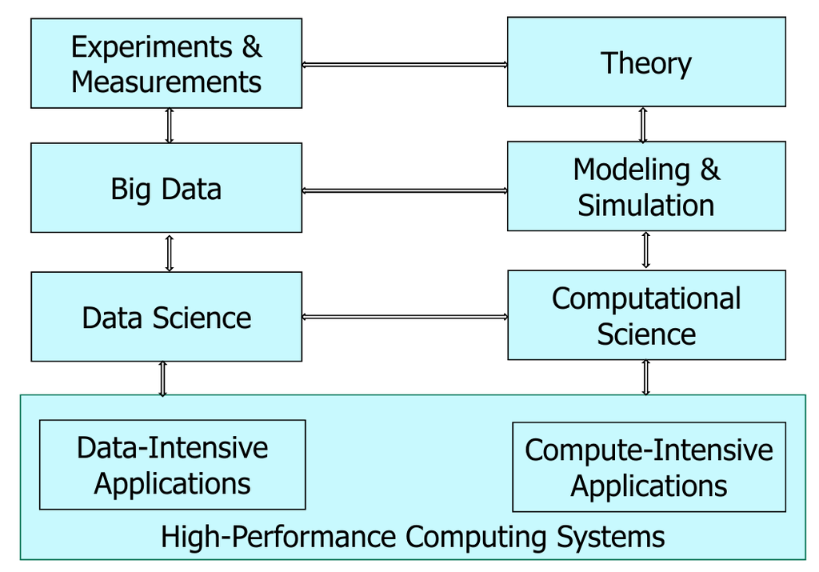

```python
Image(filename="bd_hpc.png")
```

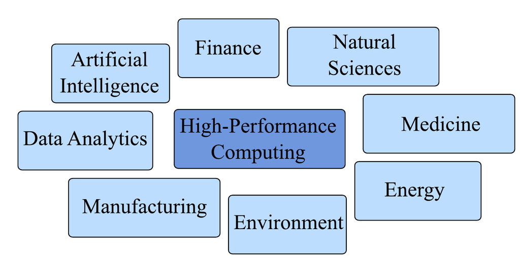

```python
Image(filename="whyhpc1.png")
```

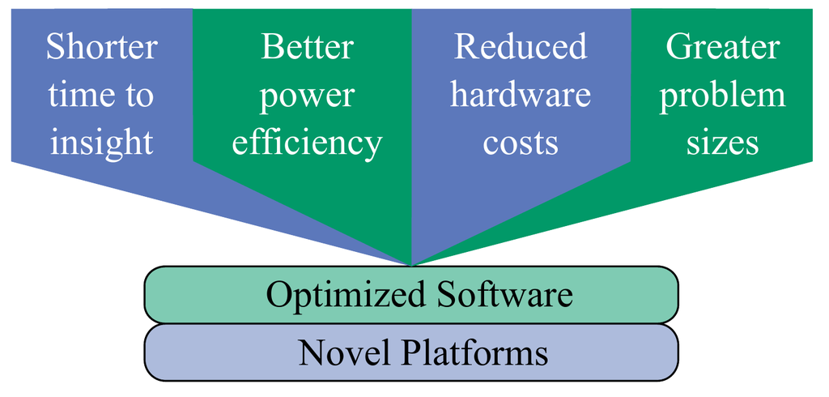

```python
Image(filename="whyhpc2.png")
```

**How is this relevant to me?** (2)

cannot just use a well equipped workstation?

[figure not shown]

```python
Image(filename="moore.png")
```

... yes but it's the same

## What is a supercomputer ?

Much of modern computational science is performed on GNU/Linux clusters where multiple processors can be utilized and many calculations can be run in parallel. The biggest, built from non off shelf hardware, are dubbed "supercomputers".

The first supercomputer of history:

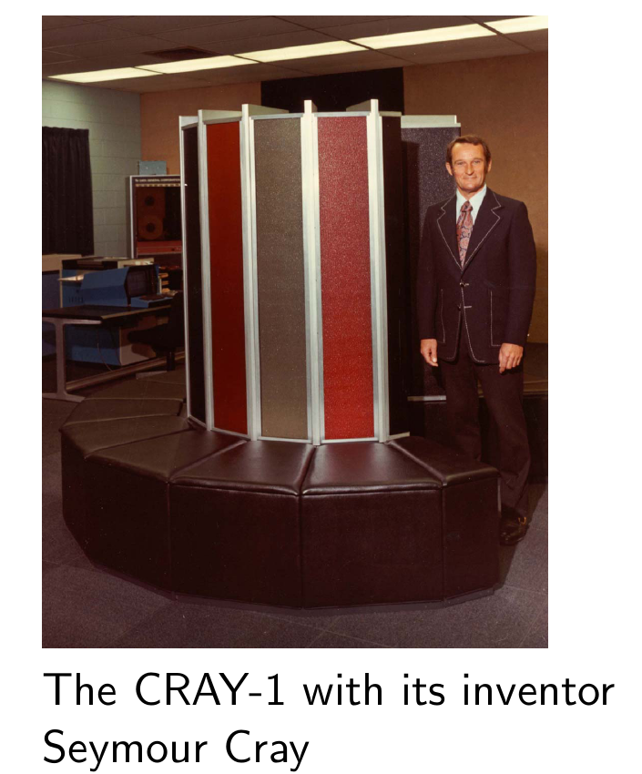

```python
Image(filename="cray.png")
```

In mid-to-late 1970’s CRAY-1 was the fastest computer in the world.

- Clock speed of 12.5ns (80MHz)
- Computaional rate of 138 MFLOPS during sustained period.

Unveiled in 1976 by its inventor Seymour Roger Cray Had spawned a new class of computer called ”The Supercomputer”.

The current listing of the "biggest of biggest" can be found on www.top500.org (see also www.green500.org)

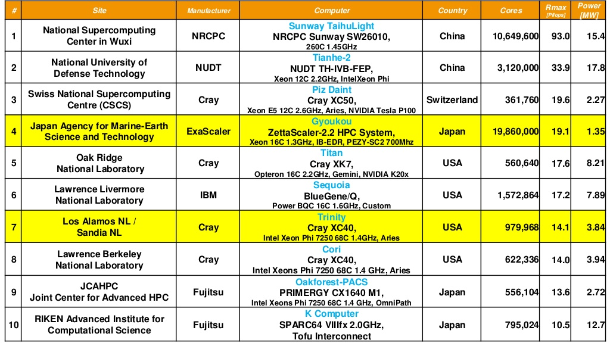

```python
Image(filename="top500-november-2017-2-1024.jpg")
```

Distribution of top500 systems in the world

[figure not shown]

```python
Image(filename="top500-november-2017-9-1024.jpg")
```

Trend over time:

[figure not shown]

```python
Image(filename="top500-november-2017-10-1024.jpg")
```

## Why we went parallel?

Long story short: we have turned to multi-core chips not because of the success of our parallel software but because of our failure to continually increase CPU frequency.

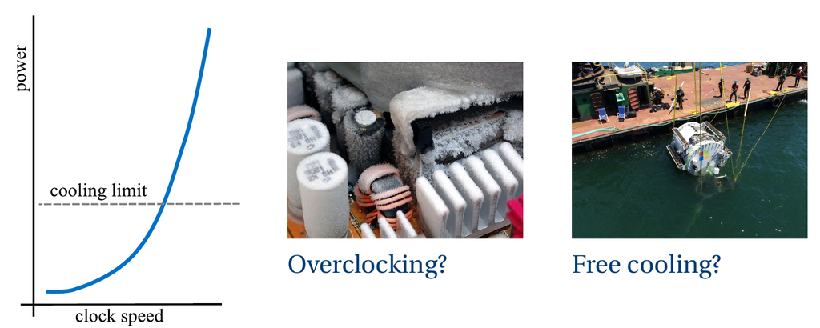

```python
Image(filename="power_wall.png")
```

note: some slides courtesy of Intel

Result: a fundamental and dangerous (for the computer industry) mismatch

- Parallel hardware is ubiquitous.
- Parallel software is rare

## What I can learn from HPC

**Band**  
amount of data moved over time unit. Measured in $bytes\ s^{-1}$ (hard disks) and $bit\ s^{-1}$ (sockets and nodes)

**Latency** minimum time needed to assign a requested resource

**Performance** number of 64 bit floating point operations per second

**Concurrency** A condition of a system in which multiple tasks are logically active at one time.

**Parallelism** A condition of a system in which multiple tasks are actually active at one time."

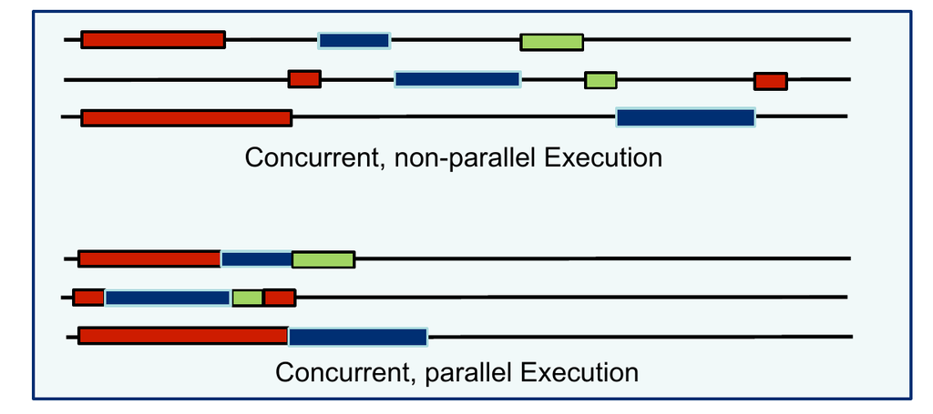

```python
Image(filename="parallel.png")
```

Parallel programming environments in the 90’s

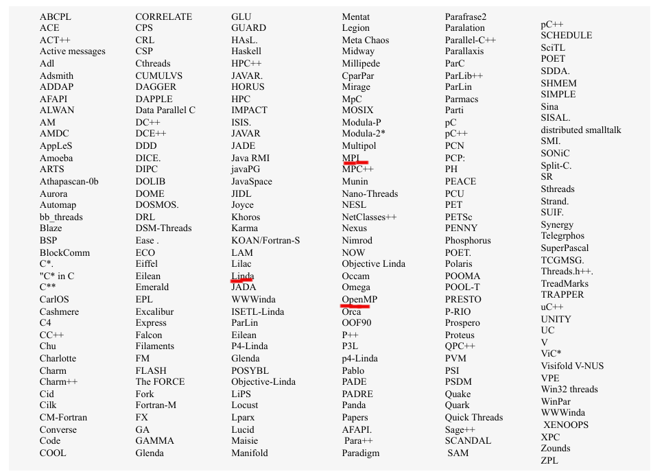

```python
Image(filename="envs90.png")
```

Environments from the literature 2010-2012:

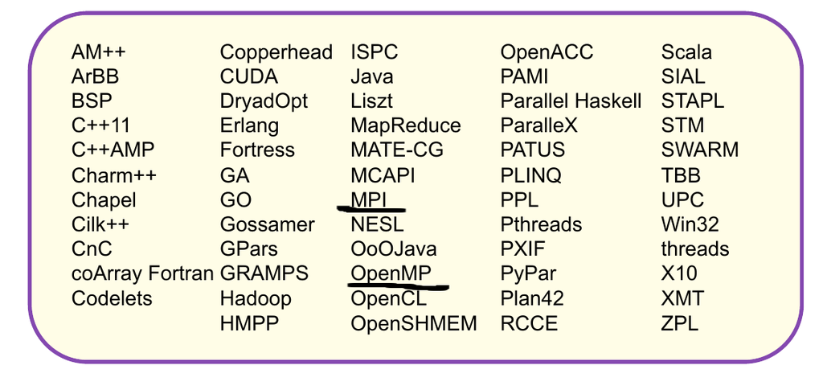

```python
Image(filename="envs10.png")
```

note: some slides courtesy of Intel

## Why bother about visualization

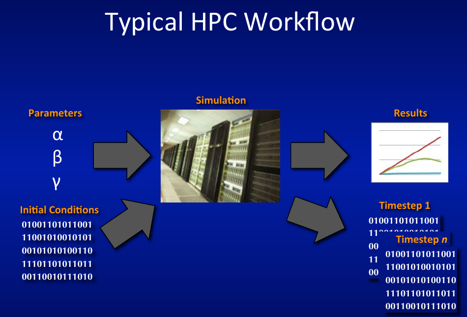

```python
Image(filename="tacc1.png")
```

disclaimer: slide took from TACC courses

[figure not shown]

```python
Image(filename="hamming.png")
```

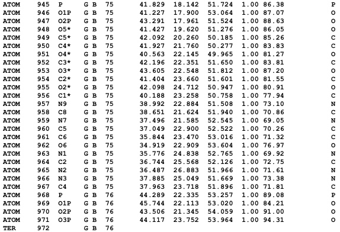

```python
Image(filename="coords.png")
```

Pages upon pages of coordinates… Insightful?

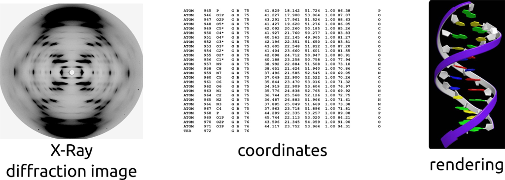

```python
Image(filename="vis.png")
```

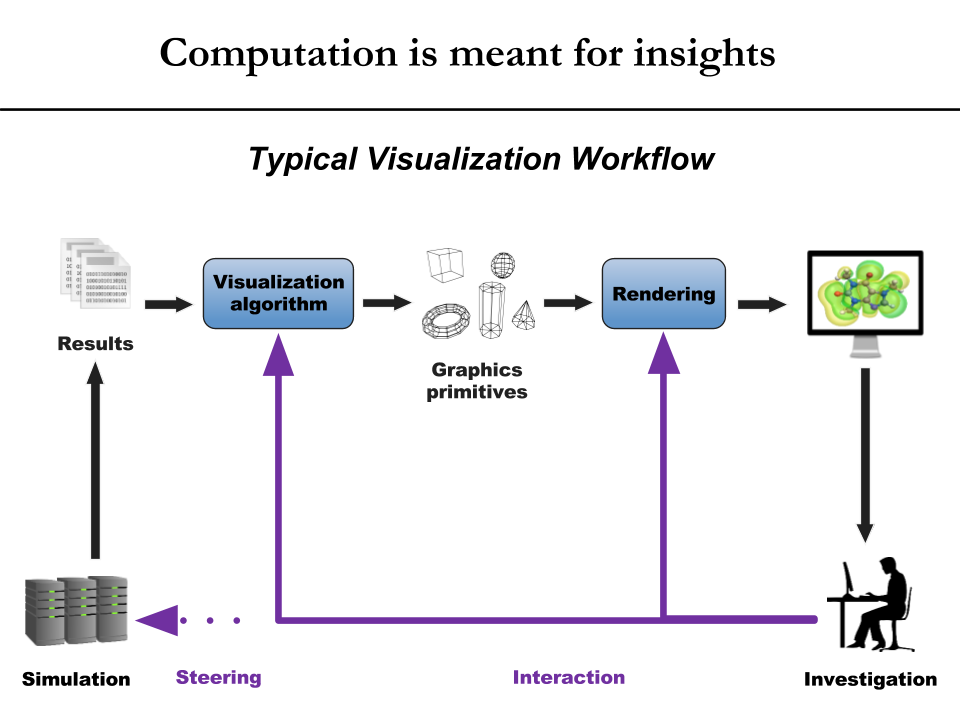

```python
Image(filename="viswork.png")
```

## Course Outline

- class 1 -- recap on CPU architecture and coprocessor usage in HPC (3h)
- class 2 -- C++ Language [1] (3h)
- class 3 -- C++ Language [2] (3h)
- class 4 -- C++ Language [3] (3h)
- class 5 -- Introduction to the model and presentation of he test case (3h)
- class 6 -- C++ Language [3] (3h)
- class 7 -- Test case design and basic performance tweaks (4h)
- class 8 -- shared memory parallel programming with OpenMP (4h)
- class 9 -- parallel programming with MPI (4h)
- class 10 -- CUDA (4h)
- class 11 -- Introduction to computer graphics and scientific visualization (2h)
- class 12 -- Computer graphics and Qt3D [1] (3h)
- class 13 -- Computer graphics and Qt3D [2] (3h)